# Predstavitev nalog

Neža Kržan

7.5.2022

# VIZUALIZACIJA TABEL ZA LAŽJE DELO

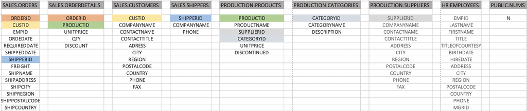

# 1. NALOGA

a.) Izpis bruto prodaje za leto 2015 za vse dobavitelje (production.suppliers > companyname)  
companyname | gross_sales

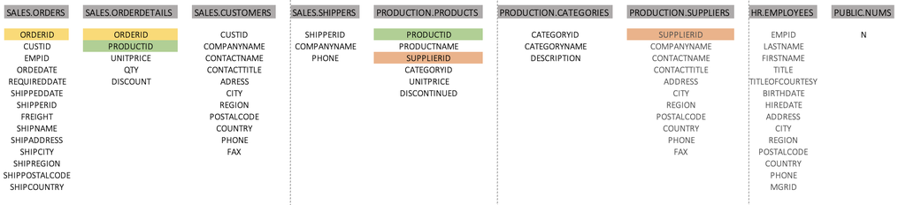

```
SELECT PRODUCTION.SUPPLIERS.COMPANYNAME, SUM(SALES.ORDERDETAILS.UNITPRICE*SALES.ORDERDETAILS.QTY) AS GROSS_SALES FROM SALES.ORDERS
INNER JOIN SALES.ORDERDETAILS ON SALES.ORDERS.ORDERID=SALES.ORDERDETAILS.ORDERID
INNER JOIN PRODUCTION.PRODUCTS ON SALES.ORDERDETAILS.PRODUCTID=PRODUCTION.PRODUCTS.PRODUCTID
INNER JOIN PRODUCTION.SUPPLIERS ON PRODUCTION.PRODUCTS.SUPPLIERID=PRODUCTION.SUPPLIERS.SUPPLIERID
WHERE ORDERDATE BETWEEN '2015-01-01' AND '2015-12-31'
GROUP BY PRODUCTION.SUPPLIERS.COMPANYNAME;
```

Izpisana tabela:

| COMPANYNAME | GROSS SALES |
| --- | --- |
| Supplier SWRXU | 12687.60 |
| Supplier VHQZD | 18230.90 |
| Supplier STUAZ | 12554.00 |
| Supplier QOVFD | 15993.20 |
| Supplier GQRCV | 51731.50 |
| Supplier BWGYE | 19447.90 |
| Supplier QQYEU | 6730.80 |
| Supplier ZPYVS | 19605.59 |
| Supplier TEGSC | 5343.60 |
| Supplier KEREV | 19634.60 |
| Supplier UHZRG | 7333.20 |
| Supplier QZGUF | 9004.00 |
| Supplier XOXZA | 4592.70 |
| Supplier FNUXM | 4118.25 |
| Supplier ELCR | 9578.85 |
| Supplier ERVYZ | 10020.35 |
| Supplier ZRYDZ | 2080.25 |
| Supplier OGLRK | 28825.20 |
| Supplier UNAHG | 1666.80 |
| Supplier SVIYA | 62799.38 |
| Supplier NZLIF | 20063.90 |
| Supplier ZWZDM | 32400.30 |
| Supplier EQPNC | 13462.60 |
| Supplier LVJUA | 52758.10 |
| Supplier JDNUG | 14715.90 |
| Supplier CIYNM | 20695.45 |
| Supplier QWUSF | 8290.05 |
| Supplier JNNES | 25574.20 |
| Supplier OAVQT | 50916.00 |

b.) Razširi izpis z dodatnim stolpcem, ki predstavlja spremembo prodaje glede na leto 2014  
companyname | gross_sales | abs_change

```
CREATE TABLE BRUTO_PRODAJA_2015 AS
SELECT PRODUCTION.SUPPLIERS.COMPANYNAME, SUM(SALES.ORDERDETAILS.UNITPRICE*SALES.ORDERDETAILS.QTY) AS GROSS_SALES FROM SALES.ORDERS
INNER JOIN SALES.ORDERDETAILS ON SALES.ORDERS.ORDERID=SALES.ORDERDETAILS.ORDERID
INNER JOIN PRODUCTION.PRODUCTS ON SALES.ORDERDETAILS.PRODUCTID=PRODUCTION.PRODUCTS.PRODUCTID
INNER JOIN PRODUCTION.SUPPLIERS ON PRODUCTION.PRODUCTS.SUPPLIERID=PRODUCTION.SUPPLIERS.SUPPLIERID
WHERE ORDERDATE BETWEEN '2015-01-01' AND '2015-12-31'
GROUP BY PRODUCTION.SUPPLIERS.COMPANYNAME;
```

```
CREATE TABLE BRUTO_PRODAJA_2014 AS
SELECT PRODUCTION.SUPPLIERS.COMPANYNAME, SUM(SALES.ORDERDETAILS.UNITPRICE*SALES.ORDERDETAILS.QTY) AS GROSS_SALES_2014 FROM SALES.ORDERS
INNER JOIN SALES.ORDERDETAILS ON SALES.ORDERS.ORDERID=SALES.ORDERDETAILS.ORDERID
INNER JOIN PRODUCTION.PRODUCTS ON SALES.ORDERDETAILS.PRODUCTID=PRODUCTION.PRODUCTS.PRODUCTID
INNER JOIN PRODUCTION.SUPPLIERS ON PRODUCTION.PRODUCTS.SUPPLIERID=PRODUCTION.SUPPLIERS.SUPPLIERID
WHERE ORDERDATE BETWEEN '2014-01-01' AND '2014-12-31'
GROUP BY PRODUCTION.SUPPLIERS.COMPANYNAME;
```

```
CREATE TABLE BRUTO_PRODAJA AS
SELECT PUBLIC.BRUTO_PRODAJA_2014.COMPANYNAME, SUM(PUBLIC.BRUTO_PRODAJA_2015.GROSS_SALES-GROSS_SALES_2014) AS ABS_CHANGE FROM PUBLIC.BRUTO_PRODAJA_2014
INNER JOIN PUBLIC.BRUTO_PRODAJA_2015 ON PUBLIC.BRUTO_PRODAJA_2014.COMPANYNAME=PUBLIC.BRUTO_PRODAJA_2015.COMPANYNAME
GROUP BY PUBLIC.BRUTO_PRODAJA_2014.COMPANYNAME;
```

```
SELECT PUBLIC.BRUTO_PRODAJA.COMPANYNAME, PUBLIC.BRUTO_PRODAJA_2015.GROSS_SALES, ABS_CHANGE FROM PUBLIC.BRUTO_PRODAJA
JOIN PUBLIC.BRUTO_PRODAJA_2015 ON PUBLIC.BRUTO_PRODAJA.COMPANYNAME=PUBLIC.BRUTO_PRODAJA_2015.COMPANYNAME;
```

Izpisana tabela:

| COMPANYNAME | GROSS CHANGE | ABS CHANGE |
| --- | --- | --- |
| Supplier EQPNC | 13462.60 | 11283.40 |
| Supplier CIYNM | 20695.45 | 16803.95 |
| Supplier KEREV | 19634.60 | 10553.80 |
| Supplier JNNES | 25574.20 | 14071.20 |
| Supplier QQYEU | 6730.80 | 6162.00 |
| Supplier BWGYE | 19447.90 | 11279.90 |
| Supplier NZLIF | 20063.90 | 13365.50 |
| Supplier ELCR | 9578.85 | 5646.45 |
| Supplier QOVFD | 15993.20 | 13501.20 |
| Supplier OGLRK | 28825.20 | 23112.20 |
| Supplier UHZRG | 7333.20 | 2323.60 |
| Supplier STUAZ | 12554.00 | 7114.00 |
| Supplier XOXZA | 4592.70 | 3345.90 |
| Supplier ZRYDZ | 2080.25 | 914.25 |
| Supplier FNUXM | 4118.25 | 3996.65 |
| Supplier VHQZD | 18230.90 | 12415.70 |
| Supplier ZWZDM | 32400.30 | 27407.10 |
| Supplier OAVQT | 50916.00 | 34177.60 |
| Supplier ZPYVS | 19605.59 | 15642.19 |
| Supplier LVJUA | 52758.10 | 24697.30 |
| Supplier UNAHG | 1666.80 | 1231.20 |
| Supplier QZGUF | 9004.00 | 5714.40 |
| Supplier ERVYZ | 10020.35 | 4763.65 |
| Supplier TEGSC | 5343.60 | 2404.20 |
| Supplier GQRCV | 51731.50 | 31705.50 |
| Supplier JDNUG | 14715.90 | 11696.80 |
| Supplier QWUSF | 8290.05 | 7021.25 |
| Supplier SWRXU | 12687.60 | 9000.40 |
| Supplier SVIYA | 62799.38 | 41994.38 |

c.) Omeji izpis s samo tistimi dobavitelji, ki so imeli več kot +10k razlike v prodaji

```
SELECT PUBLIC.BRUTO_PRODAJA_2014.COMPANYNAME, SUM(PUBLIC.BRUTO_PRODAJA_2015.GROSS_SALES-GROSS_SALES_2014) AS ABS_CHANGE FROM PUBLIC.BRUTO_PRODAJA_2014
INNER JOIN PUBLIC.BRUTO_PRODAJA_2015 ON PUBLIC.BRUTO_PRODAJA_2014.COMPANYNAME=PUBLIC.BRUTO_PRODAJA_2015.COMPANYNAME
GROUP BY PUBLIC.BRUTO_PRODAJA_2014.COMPANYNAME
HAVING ABS_CHANGE > 10000;
```

Izpisana tabela:

| COMPANYNAME | ABS CHANGE(+10k) |
| --- | --- |
| Supplier EQPNC | 11283.40 |
| Supplier CIYNM | 16803.95 |
| Supplier KEREV | 10553.80 |
| Supplier JNNES | 14071.20 |
| Supplier BWGYE | 11279.90 |
| Supplier NZLIF | 13365.50 |
| Supplier QOVFD | 13501.20 |
| Supplier OGLRK | 23112.20 |
| Supplier VHQZD | 12415.70 |
| Supplier ZWZDM | 27407.10 |
| Supplier OAVQT | 34177.60 |
| Supplier ZPYVS | 15642.19 |
| Supplier LVJUA | 24697.30 |
| Supplier GQRCV | 31705.50 |
| Supplier JDNUG | 11696.80 |
| Supplier SVIYA | 41994.38 |

d.) Vzami rezultat iz točke a.) in dodaj novi koloni - mesec in YTD gross revenue

# 2. NALOGA

a.) Izpiši celotno prodajo po letih za top 10 kupcev v letu 2014 za kategorijo “Beverages”, ki so opravili vsaj 5 nakupov (production.categories -> categoryname)  
companyname (sales.customers) | year | gross_sales

Število naročil za določen customers, ki je opravil vsaj 5 nakupov:

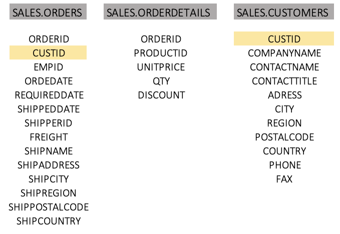

```
SELECT COMPANYNAME, EXTRACT(YEAR FROM SALES.ORDERS.ORDERDATE) AS YEAR, COUNT(SALES.ORDERS.ORDERID) AS GROSS_SALES FROM SALES.CUSTOMERS
INNER JOIN SALES.ORDERS ON SALES.CUSTOMERS.CUSTID=SALES.ORDERS.CUSTID
GROUP BY SALES.CUSTOMERS.COMPANYNAME, YEAR
HAVING GROSS_SALES >= 5;
```

Izpisana tabela:

[output not shown]

Top 10 kupcev v letu 2014:

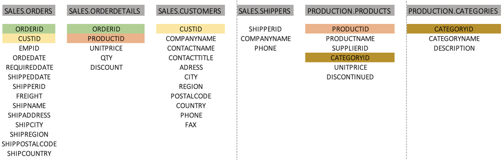

```
SELECT SALES.CUSTOMERS.COMPANYNAME, COUNT(SALES.ORDERS.ORDERID) AS GROSS_SALES FROM SALES.ORDERS
INNER JOIN SALES.CUSTOMERS ON SALES.ORDERS.CUSTID=SALES.CUSTOMERS.CUSTID
INNER JOIN SALES.ORDERDETAILS ON SALES.ORDERS.ORDERID=SALES.ORDERDETAILS.ORDERID
INNER JOIN PRODUCTION.PRODUCTS ON SALES.ORDERDETAILS.PRODUCTID=PRODUCTION.PRODUCTS.PRODUCTID
INNER JOIN PRODUCTION.CATEGORIES ON PRODUCTION.PRODUCTS.CATEGORYID=PRODUCTION.CATEGORIES.CATEGORYID
WHERE ORDERDATE BETWEEN '2014-01-01' AND '2014-12-31'AND PRODUCTION.CATEGORIES.CATEGORYID=1
GROUP BY SALES.CUSTOMERS.COMPANYNAME
ORDER BY  GROSS_SALES DESC
LIMIT 10;
```

Izpisana tabela:

| COMPANYNAME | GROSS SALES |
| --- | --- |
| Customer KIDPX | 4 |
| Customer FRXZL | 4 |
| Customer LJUCA | 4 |
| Customer SNXOJ | 3 |
| Customer QXVLA | 3 |
| Customer NYUHS | 3 |
| Customer WNMAF | 2 |
| Customer ZRNDE | 2 |
| Customer XIIWM | 2 |
| Customer AZJED | 2 |

b.) Izpiši kakšen delež predstavlja teh 10 kupcev po letih v celotni prodaji  
skupina (vrednosti top10 in ostalo) | year | delež  
*glede na to, da imamo 3 leta podatkov, mora imeti rezultat 6 vrstic

# 3. NALOGA

Izpiši za vsakega kupca koliko nakupov je v določenem razredu “trajanja med dvema nakupoma”  
Torej če je stranka opravila nakup 1.1.2020 in naslednji nakup 20.1.2020 pomeni, da je bilo med nakupoma 20 dni  
- štejemo samo tiste, ki so imeli vsaj 2 nakupa  
- predefinirani razredi - do 10 dni, med 11 in 50 dni, med 51 in 100 dni, več  
Izpis oblike:  
companyname (sales.customers) | do_10 | 11-50 | 51-100| več

```
SELECT SALES.CUSTOMERS.COMPANYNAME,COUNT(ORDERID) AS DO_10 FROM SALES.ORDERS
INNER JOIN SALES.CUSTOMERS ON SALES.ORDERS.CUSTID=SALES.CUSTOMERS.CUSTID
WHERE DATEDIFF(DAY, ORDERDATE, ORDERDATE) < 10
GROUP BY SALES.CUSTOMERS.COMPANYNAME
HAVING DO_10 >= 2;
```

Izpisana tabela:

| COMPANYNAME | DO_10 |
| --- | --- |
| Customer ENQZT | 5 |
| Customer FAPSM | 6 |
| Customer IBVRG | 11 |
| Customer SFOGW | 11 |
| Customer WNMAF | 7 |
| Customer CCKOT | 9 |
| Customer SRQVM | 8 |
| Customer UMTLM | 16 |
| Customer QNIVZ | 9 |
| Customer WULWD | 8 |
| Customer NYUHS | 13 |
| Customer THHDP | 25 |
| Customer QXVLA | 11 |
| Customer YBQTI | 13 |
| Customer IRRVL | 24 |
| Customer VONTK | 6 |
| Customer OXFRU | 15 |
| Customer XPNIK | 11 |
| Customer LHANT | 10 |
| Customer UBHAU | 9 |
| Customer JUWXK | 4 |
| Customer KSLQF | 9 |
| Customer LCYBZ | 3 |
| Customer LCOUJ | 25 |
| Customer QZURI | 5 |
| Customer XIIWM | 13 |
| Customer LOLJO | 10 |
| Customer ZRNDE | 7 |
| Customer YJCBX | 8 |
| Customer PSQUZ | 10 |

[output cut: 56 more lines]